# Solutions to Workshop 2 exercise: Catching errors

# 1 PACKAGES AND FUNCTIONS

## 1.1 Problem 1A

The code below tries to load the ‘dplyr’ package using the `p_load()` function from the `pacman` package

```r
# Incorrect code:
pacman:p_load(dplyr)
```

```
## Error in eval(expr, envir, enclos): object 'pacman' not found
```

## 1.2 Solution 1A

There should be double colons (`::`) between package name and function name

```r
# Corrected code:
pacman::p_load(dplyr)
```

Outcome: the `dplyr` package is loaded

## 1.3 Problem 1B

The `cowsay` package is an R package that allows printing of character strings as messages from animals in your console. The code below tries to load the `cowsay` package, but there is a problem

```r
# Incorrect code:
install.packages(cowsay)
```

```
## Error in eval(expr, envir, enclos): object 'cowsay' not found
```

```r
cowsay::say("Welcome to GRAPH Courses!")
```

```
## Error in loadNamespace(x): there is no package called 'cowsay'
```

## 1.4 Solution 1B

Package name in `install.packages()` should be enclosed in quotes.

```r
# Corrected code:
install.packages("cowsay")
```

Now the `cowsay` package is installed, so the following code will work:

```r
cowsay::say("Welcome to GRAPH Courses!")
```

```
##
##  --------------
## Welcome to GRAPH Courses!
##  --------------
##     \
##       \
##         \
##             |\___/|
##           ==) ^Y^ (==
##             \  ^  /
##              )=*=(
##             /     \
##             |     |
##            /| | | |\
##            \| | |_|/\
##       jgs  //_// ___/
##                \_)
##
```

# 2 STRING MANIPULATION

Each block of code in this section attempts to perform a string manipulation, but contains an error. Identify and correct these errors.

## 2.1 Problem 2A

The code below tries to concatenate (join) two strings.

```r
# Incorrect code:
first_name <- Ash
```

```
## Error in eval(expr, envir, enclos): object 'Ash' not found
```

```r
last_name <- Ketchum
```

```
## Error in eval(expr, envir, enclos): object 'Ketchum' not found
```

```r
paste(first_name, last_name)
```

```
## Error in eval(expr, envir, enclos): object 'first_name' not found
```

## 2.2 Solution 2A

Strings should be enclosed in quotes.

```r
# Corrected code:
first_name <- "Ash"
last_name <- "Ketchum"
```

The two text strings have been assigned to objects (see your Environment tab), so now the `paste()` function will recognize and concatenate them.

```r
paste(first_name, last_name)
```

```
## [1] "Ash Ketchum"
```

## 2.3 Problem 2B

The code below tries to combine (join) two strings into one.

```r
# Incorrect code:
first_name <- "John"
last_name <- "Doe"
full_name <- first_name + last_name
```

```
## Error in first_name + last_name: non-numeric argument to binary operator
```

```r
full_name
```

```
## Error in eval(expr, envir, enclos): object 'full_name' not found
```

## 2.4 Solution 2B

Use `paste()` instead of the plus sign (`+`) to join strings.

```r
# Corrected code:
first_name <- "John"
last_name <- "Doe"
full_name <- paste(first_name, last_name)
full_name
```

```
## [1] "John Doe"
```

# 3 ARITHMETIC

## 3.1 Problem 3A

A patient took 12000 steps on Monday and 15000 steps on Tuesday. The code below tries to calculate the average number of steps taken by a patient.

```r
# Incorrect code:
steps_monday <- 12000
steps_tuesday <- 15000
average_steps <- steps_monday + steps_tuesday / 2
average_steps
```

```
## [1] 19500
```

The code runs without giving an error, but the result is incorrect. The average of 12000 and 15000 is not 19500.

## 3.2 Solution 3A

Parentheses are needed around the sum of steps before dividing by 2.

```r
# Corrected code:
steps_monday <- 12000
steps_tuesday <- 15000
average_steps <- (steps_monday + steps_tuesday) / 2
average_steps
```

```
## [1] 13500
```

## 3.3 Problem 3B

There are 500 smokers in a population of 20000. The code below attempts to calculate the percentage of smokers in the population.

```r
# Incorrect code:
total_population <- 20000
smokers <- 500
percentage_smokers <- (smokers ÷ total_population) * 100
percentage_smokers
```

```
## Error: <text>:4:32: unexpected input
## 3: smokers <- 500
## 4: percentage_smokers <- (smokers ÷
##                                   ^
```

## 3.4 Solution 3B

Use slash (`/`) instead of the division symbol (÷).

```r
# Corrected code:
total_population <- 20000
smokers <- 500
percentage_smokers <- (smokers / total_population) * 100
percentage_smokers
```

```
## [1] 2.5
```

# 4 NAMING R OBJECTS

Each block of code in this section attempts to create an R object, but contains an error related to the rules for naming R objects. Identify and correct these errors.

## 4.1 Problem 4A

```r
# Incorrect code:
1st_student <- "John Doe"
1st_student
```

```
## Error: <text>:2:2: unexpected symbol
## 1: # Incorrect code:
## 2: 1st_student
##     ^
```

Object names cannot start with a number.

## 4.2 Solution 4A

```r
# Corrected code:
first_student <- "John Doe"
first_student
```

```
## [1] "John Doe"
```

## 4.3 Problem 4B

```r
# Incorrect code:
total population <- 10000
total population
```

```
## Error: <text>:2:7: unexpected symbol
## 1: # Incorrect code:
## 2: total population
##          ^
```

Object names cannot contain spaces.

## 4.4 Solution 4B

```r
# Corrected code:
total_population <- 10000
total_population
```

```
## [1] 10000
```

This is just one possible solution. You can use period case (e.g., `total.population`) or camel case (e.g., `totalPopulation`) to name objects.

## 4.5 Problem 4C

```r
# Incorrect code:
R-object <- "Sample data"
```

```
## Error: object 'R' not found
```

```r
R-object
```

```
## Error in eval(expr, envir, enclos): object 'R' not found
```

Object names cannot contain hyphens.

## 4.6 Solution 4C

```r
# Corrected code:
R_object <- "Sample data"
R_object
```

```
## [1] "Sample data"
```

# 5 INCORRECT FUNCTION USAGE

Each block of code attempts to call a function, but contains an error. Identify and correct these errors.

## 5.1 Problem 5A

```r
# Incorrect code:
sqrt("16")
```

```
## Error in sqrt("16"): non-numeric argument to mathematical function
```

## 5.2 Solution 5A

The argument should be a numeric value, not a character.

```r
# Corrected code:
sqrt(16)
```

```
## [1] 4
```

## 5.3 Problem 5B

The code below tries to calculate the square root of a number.

```r
# Incorrect code:
sqrt[16]
```

```
## Error in sqrt[16]: object of type 'builtin' is not subsettable
```

## 5.4 Solution 5B

Use parentheses instead of square brackets for function calls.

```r
# Corrected code:
sqrt(16)
```

```
## [1] 4
```

## 5.5 Problem 5C

The code below tries to get the first 5 rows of the `iris` dataframe.

```r
# Incorrect code:
head(5, iris)
```

```
## Error in checkHT(n, dx <- dim(x)): invalid 'n' - must be numeric, possibly NA.
```

The arguments are in the wrong order and they are not named.

## 5.6 Solution 5C

R expects the first argument of the `head()` function to be the object you want to return (`iris` dataframe) and the second should be the number of rows.

```r
# Corrected code:
head(iris, 5)
```

```
##   Sepal.Length Sepal.Width Petal.Length Petal.Width Species
## 1          5.1         3.5          1.4         0.2  setosa
## 2          4.9         3.0          1.4         0.2  setosa
## 3          4.7         3.2          1.3         0.2  setosa
## 4          4.6         3.1          1.5         0.2  setosa
## 5          5.0         3.6          1.4         0.2  setosa
```

If you name the arguments, the order no longer matters.

```r
# Alternate solution:
head(n = 5, x = iris)
```

```
##   Sepal.Length Sepal.Width Petal.Length Petal.Width Species
## 1          5.1         3.5          1.4         0.2  setosa
## 2          4.9         3.0          1.4         0.2  setosa
## 3          4.7         3.2          1.3         0.2  setosa
## 4          4.6         3.1          1.5         0.2  setosa
## 5          5.0         3.6          1.4         0.2  setosa
```

# 6 OBJECT NOT FOUND

Each block of code in this section attempts to use an R object, but contains an error because the object is not found. Identify and correct these errors.

## 6.1 Problem 6A

The code below tries to calculate the mean of a sequence of tumor sizes.

```r
# Incorrect code:
tumor_sizes_in_cm <- c(1, 4, 2, 1, 3)
mean(tumor_sizes_1n_cm)
```

```
## Error in eval(expr, envir, enclos): object 'tumor_sizes_1n_cm' not found
```

NOTE that `c()` is a function to combine the items together. It is correct code. The problem is in the second line.

## 6.2 Solution 6A

Fix the typo in the object name (change `1` to `i`).

```r
# Corrected code:
tumor_sizes_in_cm <- c(1, 4, 2, 1, 3)
mean(tumor_sizes_in_cm)
```

```
## [1] 2.2
```

## 6.3 Problem 6B

The code below tries to plot the height of women in the `women` dataset.

```r
# Incorrect code:
Height_Women <- women$height
plot(Height__women)
```

```
## Error in eval(expr, envir, enclos): object 'Height__women' not found
```

The problem is in the second line.

## 6.4 Solution 6B

Fix two types in the object name (lower case `w` should be uppercase `W`, and there is an extra underscore `_`).

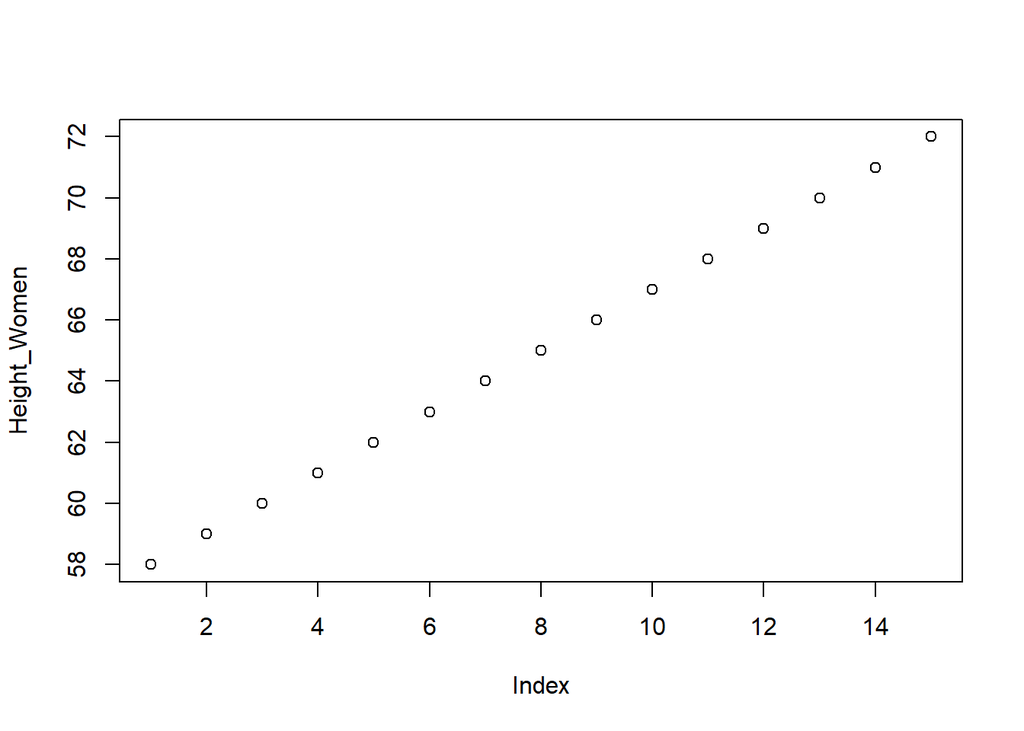

```r
# Corrected code:
Height_Women <- women$height
plot(Height_Women)
```

# 7 FUNCTION NESTING/ INTERMEDIATE OBJECTS

Each block of code contains an error involving improper function nesting or intermediate objects.

## 7.1 Problem 7A

The code below tries to use function nesting to plot the head (first 6 rows) of the `women` dataset. Identify and fix the error. CLUE: It involves function order.

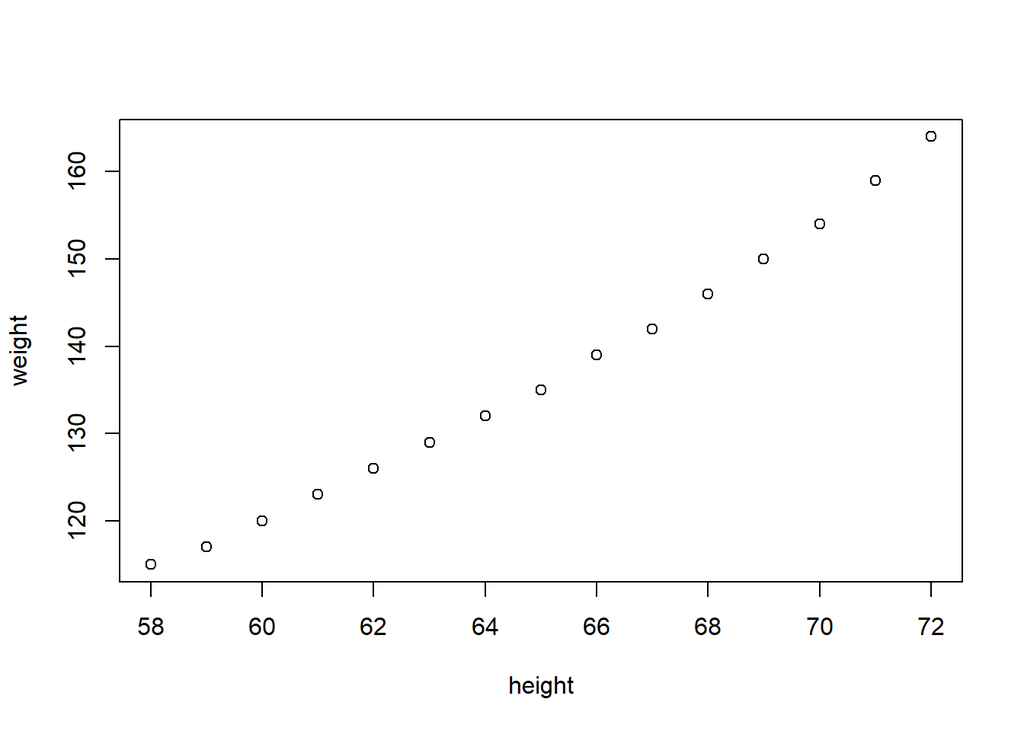

```r
# Incorrect code:
head(plot(women))
```

## 7.2 Solution 7A

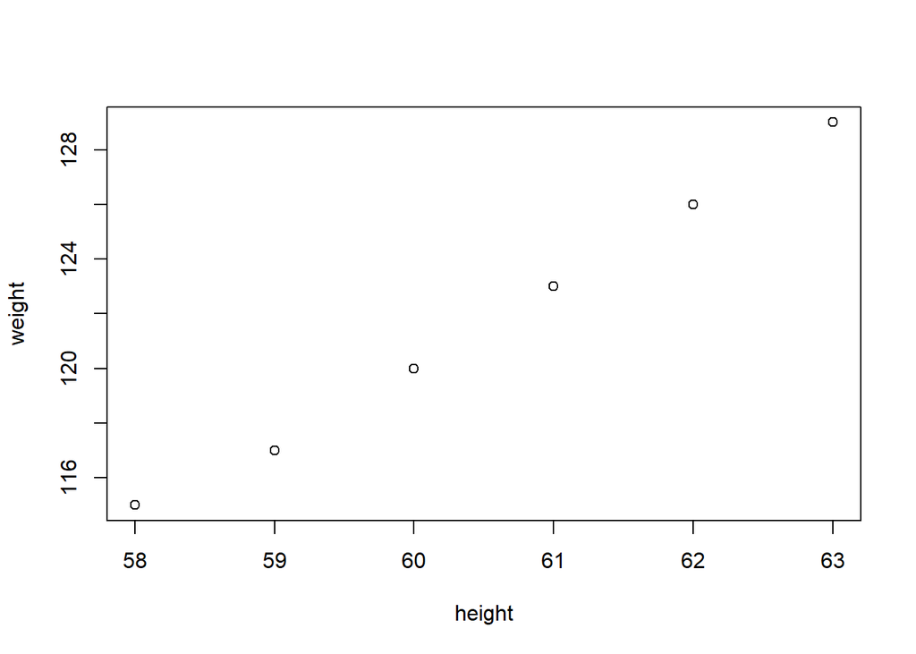

```r
# Corrected code:
plot(head(women))
```

## 7.3 Problem 7B

The code below tries to plot the head (first 6 rows) of the `women` dataset by assigning an intermediate object. There is a problem on the second line though. Identify and fix it.

```r
# Incorrect code:
head_women <- head(women)
plot(head)
```

```
## Error in curve(expr = x, from = from, to = to, xlim = xlim, ylab = ylab, : 'expr' did not evaluate to an object of length 'n'
```

## 7.4 Soltion 7B

The plot function should use the intermediate object (`head_women`) as its argument (not `head`).

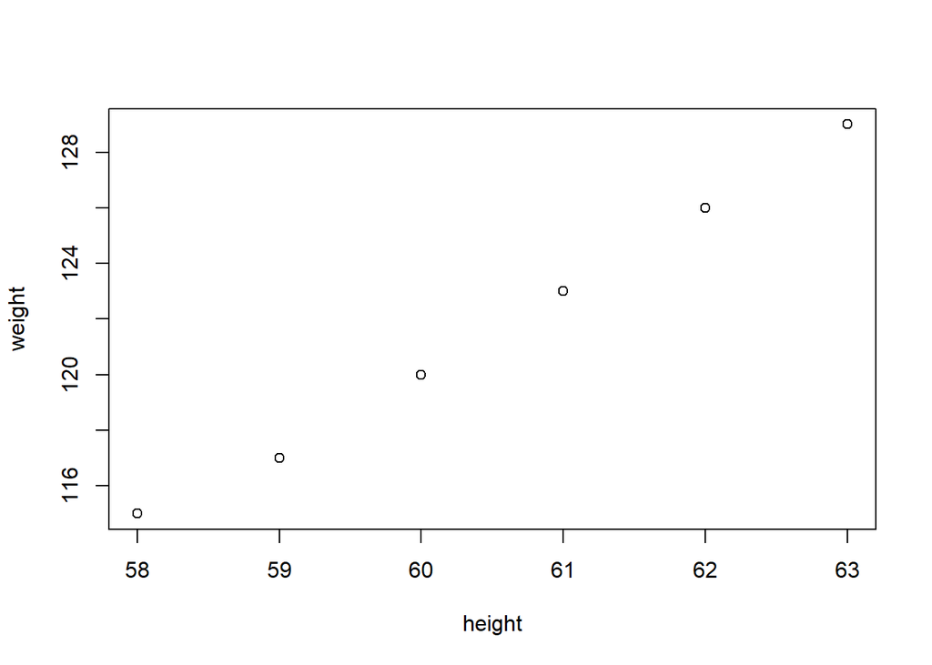

```r
# Corrected code:
head_women <- head(women)
plot(head_women)
```

# 8 MISSING OR MISPLACED CHARACTERS

Each block of code contains an error involving a missing or misplaced character. Identify and correct these errors.

## 8.1 Problem 8A

The code below tries to concatenate (join) two strings.

```r
# Incorrect code:
first_name <- "John"
last_name <- "Doe"
joined_name <- paste(first_name last_name)
joined_name
```

```
## Error: <text>:4:33: unexpected symbol
## 3: last_name <- "Doe"
## 4: joined_name <- paste(first_name last_name
##                                    ^
```

## 8.2 Solution 8A

Add a comma between the two arguments in `paste()`

```r
# Corrected code:
first_name <- "John"
last_name <- "Doe"
joined_name <- paste(first_name, last_name)
joined_name
```

```
## [1] "John Doe"
```

## 8.3 Problem 8B

The code below tries to view the top 10 rows of the iris dataframe.

```r
# Incorrect code:
head(x = iris, n = 10))
```

```
## Error: <text>:2:23: unexpected ')'
## 1: # Incorrect code:
## 2: head(x = iris, n = 10))
##                          ^
```

## 8.4 Solution 8B

Remove the extra closing parenthesis.

```r
# Corrected code:
head(x = iris, n = 10)
```

```
##    Sepal.Length Sepal.Width Petal.Length Petal.Width Species
## 1           5.1         3.5          1.4         0.2  setosa
## 2           4.9         3.0          1.4         0.2  setosa
## 3           4.7         3.2          1.3         0.2  setosa
## 4           4.6         3.1          1.5         0.2  setosa
## 5           5.0         3.6          1.4         0.2  setosa
## 6           5.4         3.9          1.7         0.4  setosa
## 7           4.6         3.4          1.4         0.3  setosa
## 8           5.0         3.4          1.5         0.2  setosa
## 9           4.4         2.9          1.4         0.2  setosa
## 10          4.9         3.1          1.5         0.1  setosa
```

## 8.5 Problem 8C

The code below tries to create an R object with a character value.

```r
# Incorrect code:
name <- toupper('John Doe")
```

```
## Error: <text>:2:17: unexpected INCOMPLETE_STRING
## 1: # Incorrect code:
## 2: name <- toupper('John Doe")
##                    ^
```

## 8.6 Solution 8C

Fix the mismatched quotes by changing them both to single `'` or double quotes `"`.

```r
# Corrected code:
name <- toupper("John Doe")
```